# HW2_310700021

```python
import numpy as np
import pandas as pd
```

```python
#read data
df = pd.read_csv('health.dat.txt', sep=" ",header=None)
print(df)
```

```
         0    1    2   3     4    5     6     7       8       9   ...    14  \
0        id  bac  hsp  er  hypo  inj  pump  smbg  health   wt.kg  ...  race
1     10017    1    1   1     2    2     1   3.5       2     NaN  ...     1
2     10017    2    1   1     2    3     1     4       2     NaN  ...     1
3     10017    3    1   1     2    3     1   3.5       3     NaN  ...     1
4     10017    4    1   1     2    3     1   3.5       2    40.3  ...     1
...     ...  ...  ...  ..   ...  ...   ...   ...     ...     ...  ...   ...
8628  19174    8    1   2     2    2     1     4       1    55.3  ...     1
8629  19174   20    1   1     2    2     1   3.5       2    60.7  ...     1
8630  19174   21    1   1     2    2     1   3.5       2    58.9  ...     1
8631  19174   22    1   1     2    2     1   3.5       1    58.9  ...     1
8632  19174   23    2   2     2    3     1     4       1  58.968  ...     1

        15         16       17      18      19    20         21      22  \
0     tsei  edu.level  edu.yrs  bacage  bacdur  inj3  tot.units    mghb
```

[output cut: 25 more lines]

```python
df
```

|  | 0 | 1 | 2 | 3 | 4 | 5 | 6 | 7 | 8 | 9 | ... | 14 | 15 | 16 | 17 | 18 | 19 | 20 | 21 | 22 | 23 |
| --- | --- | --- | --- | --- | --- | --- | --- | --- | --- | --- | --- | --- | --- | --- | --- | --- | --- | --- | --- | --- | --- |
| 0 | id | bac | hsp | er | hypo | inj | pump | smbg | health | wt.kg | ... | race | tsei | edu.level | edu.yrs | bacage | bacdur | inj3 | tot.units | mghb | dose |
| 1 | 10017 | 1 | 1 | 1 | 2 | 2 | 1 | 3.5 | 2 | NaN | ... | 1 | 0.1 | 2 | 12 | 7.5373 | 1.1937 | 1 | 16.5 | 12.955 | NaN |
| 2 | 10017 | 2 | 1 | 1 | 2 | 3 | 1 | 4 | 2 | NaN | ... | 1 | 0.1 | 2 | 12 | 7.9781 | 1.6345 | 2 | 19.5 | 12.955 | NaN |
| 3 | 10017 | 3 | 1 | 1 | 2 | 3 | 1 | 3.5 | 3 | NaN | ... | 1 | 0.1 | 2 | 12 | 8.4463 | 2.1027 | 2 | 22.5 | 12.955 | NaN |
| 4 | 10017 | 4 | 1 | 1 | 2 | 3 | 1 | 3.5 | 2 | 40.3 | ... | 1 | 0.1 | 2 | 12 | 8.909 | 2.5654 | 2 | 26 | 12.955 | 0.6452 |
| ... | ... | ... | ... | ... | ... | ... | ... | ... | ... | ... | ... | ... | ... | ... | ... | ... | ... | ... | ... | ... | ... |
| 8628 | 19174 | 8 | 1 | 2 | 2 | 2 | 1 | 4 | 1 | 55.3 | ... | 1 | 21.1 | 2 | 12 | 14.609 | 5.0979 | 1 | 76 | 9.28 | 1.3743 |
| 8629 | 19174 | 20 | 1 | 1 | 2 | 2 | 1 | 3.5 | 2 | 60.7 | ... | 1 | 21.1 | 2 | 12 | 16.665 | 7.154 | 1 | 87.5 | 9.28 | 1.4415 |
| 8630 | 19174 | 21 | 1 | 1 | 2 | 2 | 1 | 3.5 | 2 | 58.9 | ... | 1 | 21.1 | 2 | 12 | 17.216 | 7.7043 | 1 | 83.5 | 9.28 | 1.4177 |
| 8631 | 19174 | 22 | 1 | 1 | 2 | 2 | 1 | 3.5 | 1 | 58.9 | ... | 1 | 21.1 | 2 | 12 | 17.58 | 8.0684 | 1 | 86.5 | 9.28 | 1.4686 |
| 8632 | 19174 | 23 | 2 | 2 | 2 | 3 | 1 | 4 | 1 | 58.968 | ... | 1 | 21.1 | 2 | 12 | 18.294 | 8.783 | 2 | 65.5 | 9.28 | 1.1108 |

8633 rows × 24 columns

```python
#reset header
new_header = df.iloc[0]
df = df[1:]
df.columns = new_header
```

```python
#keep x y
df = df[['mghb', 'edu.level']]
```

```python
df = df.dropna(axis=0) #刪除有缺失的row
```

```python
df['edu.level'].value_counts() #不應該有0
```

```
2    3064
4    1700
5    1601
3    1263
6     535
1     394
0       4
Name: edu.level, dtype: int64
```

```python
df = df[df['edu.level'] != '0'] #drop 0
```

```python
df['edu.level'].value_counts()
```

```
2    3064
4    1700
5    1601
3    1263
6     535
1     394
Name: edu.level, dtype: int64
```

```python
df['mghb'].value_counts()
```

```
11.879    43
12.352    42
11.916    38
10.718    34
12.279    33
          ..
9.34       1
9.62       1
9.6733     1
14         1
8.8        1
Name: mghb, Length: 544, dtype: int64
```

```python
df = df.astype(float)
```

```python
df
```

|  | mghb | edu.level |
| --- | --- | --- |
| 1 | 12.955 | 2.0 |
| 2 | 12.955 | 2.0 |
| 3 | 12.955 | 2.0 |
| 4 | 12.955 | 2.0 |
| 5 | 12.955 | 2.0 |
| ... | ... | ... |
| 8628 | 9.280 | 2.0 |
| 8629 | 9.280 | 2.0 |
| 8630 | 9.280 | 2.0 |
| 8631 | 9.280 | 2.0 |
| 8632 | 9.280 | 2.0 |

8557 rows × 2 columns

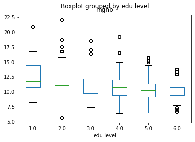

```python
df.boxplot(by ='edu.level', column =['mghb'], grid = False) #boxplot
```

```python
# clean outlier
q_low = df['mghb'].quantile(0.01)
q_hi  = df['mghb'].quantile(0.99)

df_filtered = df[(df['mghb'] < q_hi) & (df['mghb'] > q_low)]
```

```python
df_filtered
```

|  | mghb | edu.level |
| --- | --- | --- |
| 1 | 12.955 | 2.0 |
| 2 | 12.955 | 2.0 |
| 3 | 12.955 | 2.0 |
| 4 | 12.955 | 2.0 |
| 5 | 12.955 | 2.0 |
| ... | ... | ... |
| 8628 | 9.280 | 2.0 |
| 8629 | 9.280 | 2.0 |
| 8630 | 9.280 | 2.0 |
| 8631 | 9.280 | 2.0 |
| 8632 | 9.280 | 2.0 |

8361 rows × 2 columns

```python
x = pd.get_dummies(df_filtered['edu.level']) #create dummies
```

```python
x = x.iloc[: , :-1] # drop last col to make k-1 dummies
```

```python
x
```

|  | 1.0 | 2.0 | 3.0 | 4.0 | 5.0 |
| --- | --- | --- | --- | --- | --- |
| 1 | 0 | 1 | 0 | 0 | 0 |
| 2 | 0 | 1 | 0 | 0 | 0 |
| 3 | 0 | 1 | 0 | 0 | 0 |
| 4 | 0 | 1 | 0 | 0 | 0 |
| 5 | 0 | 1 | 0 | 0 | 0 |
| ... | ... | ... | ... | ... | ... |
| 8628 | 0 | 1 | 0 | 0 | 0 |
| 8629 | 0 | 1 | 0 | 0 | 0 |
| 8630 | 0 | 1 | 0 | 0 | 0 |
| 8631 | 0 | 1 | 0 | 0 | 0 |
| 8632 | 0 | 1 | 0 | 0 | 0 |

8361 rows × 5 columns

```python
df_filtered = df_filtered.iloc[: , :-1]
```

```python
res = pd.concat([df_filtered,x],axis=1) #concat 2 df
```

```python
res
```

|  | mghb | 1.0 | 2.0 | 3.0 | 4.0 | 5.0 |
| --- | --- | --- | --- | --- | --- | --- |
| 1 | 12.955 | 0 | 1 | 0 | 0 | 0 |
| 2 | 12.955 | 0 | 1 | 0 | 0 | 0 |
| 3 | 12.955 | 0 | 1 | 0 | 0 | 0 |
| 4 | 12.955 | 0 | 1 | 0 | 0 | 0 |
| 5 | 12.955 | 0 | 1 | 0 | 0 | 0 |
| ... | ... | ... | ... | ... | ... | ... |
| 8628 | 9.280 | 0 | 1 | 0 | 0 | 0 |
| 8629 | 9.280 | 0 | 1 | 0 | 0 | 0 |
| 8630 | 9.280 | 0 | 1 | 0 | 0 | 0 |
| 8631 | 9.280 | 0 | 1 | 0 | 0 | 0 |
| 8632 | 9.280 | 0 | 1 | 0 | 0 | 0 |

8361 rows × 6 columns

```python
# simple regression
import statsmodels.api as sm
from statsmodels.sandbox.regression.predstd import wls_prediction_std

X = res.iloc[: , 1:]
y = res['mghb']
```

```python
X = sm.add_constant(X)   #增加模型的常數

model0 = sm.OLS(y,X)    #OLS回歸
results0 = model0.fit()

print(results0.summary())
```

```
                            OLS Regression Results
==============================================================================
Dep. Variable:                   mghb   R-squared:                       0.042
Model:                            OLS   Adj. R-squared:                  0.041
Method:                 Least Squares   F-statistic:                     73.30
Date:                Wed, 28 Sep 2022   Prob (F-statistic):           2.29e-75
Time:                        00:20:39   Log-Likelihood:                -16494.
No. Observations:                8361   AIC:                         3.300e+04
Df Residuals:                    8355   BIC:                         3.304e+04
Df Model:                           5
Covariance Type:            nonrobust
==============================================================================
                 coef    std err          t      P>|t|      [0.025      0.975]
------------------------------------------------------------------------------
const         10.1398      0.076    132.972      0.000       9.990      10.289
1.0            1.8753      0.119     15.759      0.000       1.642       2.109
2.0            0.8793      0.083     10.644      0.000       0.717       1.041
3.0            0.7382      0.091      8.124      0.000       0.560       0.916
4.0            0.7885      0.087      9.021      0.000       0.617       0.960
5.0            0.3044      0.088      3.460      0.001       0.132       0.477
==============================================================================
Omnibus:                      183.535   Durbin-Watson:                   0.134
Prob(Omnibus):                  0.000   Jarque-Bera (JB):              195.445
Skew:                           0.374   Prob(JB):                     3.63e-43
Kurtosis:                       3.032   Cond. No.                         11.4
==============================================================================

Notes:
[1] Standard Errors assume that the covariance matrix of the errors is correctly specified.
```

1.(25%) Do a simple regression of GHb on EDU LEVEL. What are the interpretations of regression coefficients (slope and intercept)?

根據模型 ： y = 10.1398(b0) +1.8753*D1+0.8793*D2+ 0.7382*D3+0.7885*D4+0.3044*D5 模型截距項 = 10.1398. 虛擬變數Ｄ1對y影響最大，係數1.8753 ，當D1 =1 ，mghb上升1.8753％

2.(25%) What is the significance of the coefficients? What does it means? 對回歸係數進行t檢定， h0 : bi == 0 h1 : bi != 0 判斷自變數對依變數是否具有影響。上方可看出 pvalue皆小於0.05。落於拒絕域，reject h0。表示自變數對依變數具有影響力。

3.(25%) What are the predicted values of GHb for children whose mother's education level equals to 2, equal to 6?

mother's education level equals to 2 D2 =1 y = 11.01909265

mother's education level equals to 6 ，D1-D5皆為0 y = 10.1398382

```python
#predict y
new_x = ([0,1,0,0,0],
         [0,0,0,0,0])
new_x = sm.add_constant(new_x)

y_predict = results0.predict(new_x)
print(y_predict)
```

```
[11.01909265 10.1398382 ]
```

4.Can you calculate a 95% CI for the mean GHb for those children whose mothers have a bachelor's degree? If yes, what is the CI? If no, what information do you need to get the CI?

```python
new_x = ([0,0,0,0,1],
         [0,0,0,0,0])
new_x = sm.add_constant(new_x)

predictions = results0.get_prediction(new_x)
predictions.summary_frame(alpha=0.05)
```

|  | mean | mean_se | mean_ci_lower | mean_ci_upper | obs_ci_lower | obs_ci_upper |
| --- | --- | --- | --- | --- | --- | --- |
| 0 | 10.444274 | 0.043914 | 10.358192 | 10.530356 | 7.031251 | 13.857297 |
| 1 | 10.139838 | 0.076256 | 9.990359 | 10.289318 | 6.724628 | 13.555048 |

```python
# [0]表示 bachelor's degree

# mean 95% ci_upper = 10.5305
# mean 95% ci_lower = 10.3581
```